# **[Universidade Federal Rural de Pernambuco](http://ufrpe.br/)** **[Departamento de Matemática](http://www.dm.ufrpe.br/)** **[Disciplina: Cálculo M I](https://sites.google.com/site/ricardonunesmachadojr/disciplinas/c%C3%A1lculo-mi)** **[Prof. Ricardo Machado](https://sites.google.com/site/ricardonunesmachadojr/)**

## [Índice de Aulas](https://sagectu.com.br/calculo1.github.io/index.html) Aula 10

## Polinômio de Taylo de grau 1 Polinômio de Taylo de grau 2 Polinômio de Taylo de grau $n$

# Referências:

[figure not shown]

[figure not shown]

### Observação: Nota de aula produzida usando o software [SageMath](http://www.sagemath.org/), usando o notbook [Jupyter](https://jupyter.org/). Use o SageMathCell com vários exemplos em: sagectu.com.br/sagecell.html

## 1 - Polinômio de Taylor de grau 1

## Fórmula de Taylor A Fórmula de Taylor nos fornece uma regra para determinar o polinômio de grau $n$ que melhor aproxima uma dada função ao redor de um ponto $x_0$ interior ao seu domínio.

## O exemplo mais simples de aproximação de uma função por um polinômio é a aproximação linear que estudamos anteriormente. Assim como naquele caso, vamos considerar a reta tangente ao gráfico de $f(x)$ no ponto $x = x_0$ $$L(x) = f(x_0) + f'(x_0)(x − x_0)$$ para aproximar o gráfico da função $f(x)$ para $x$ no ao redor de $x_0$. A idéia é aproximar o gráfico de $f(x)$ ao redor de $(x_0, f(x_0))$ pelo gráfico de uma função linear $L(x)$ que passe pelo mesmo ponto e tal que $L'(x_0) = f'(x_0)$.

## Definimos o erro que se comete ao aproximar $f(x)$ por $L(x)$ por $$E(x) = f(x) − L(x).$$ Observemos que, para $x\neq x_0$, temos $$ \frac{E(x)}{x-x_0} = \frac{f(x)-f(x_0)-f'(x_0)(x − x_0)}{x-x_0} = \frac{f(x)-f(x_0)}{x-x_0}-f'(x_0)$$ Daí, $$ \lim_{x\rightarrow x_0} \frac{E(x)}{x-x_0} = 0, $$ ou seja, quando $x \rightarrow p$, o erro $E(x)$ tende a zero mais rapidamente do que $|x − x_0|$.

## Então definimos o polinômio de Taylor de ordem 1 de $f(x)$ ao redor de $x_0$ por $$P(x) = f(x_0) + f'(x_0)(x-x_0) $$ e $P$ á a função linear que melhor aproxima localmente $f(x)$ ao redor de $x_0$.

## Exemplo 1 Usando o polinômio de Taylor de grau 1, calcule $\ln(1,003)$

## Solução Seja $f(x)=\ln(x)$, então $f'(x) = \frac{1}{x}$. O polinômio de Taylor de grau 1, de $f$ em volta de $x_0=1$ é: $$ P(x) = f(1)+f'(1)(x-1) = 0 + \frac{1}{1}(x-1) = x-1$$ E portanto $$ P(1,003) = 1,003-1 = 0,003. $$

```python
log(1.003)
```

```
0.00299550897979837
```

## 2 - Polinômio de Taylor de grau 2

## Suponhamos agora que a função $f(x)$ seja duas vezes diferenciável e procuremos um polinômio $P(x)$, de grau no máximo $2$, tal que $$ f(x_0) = P(x_0), ~ f'(x_0) = P'(x_0) \text{ e } f''(x_0) = P''(x_0).$$ Devemos procurar $P(x)$ na forma $$P(x) = c_0 + c_1(x − x_0) + c_2(x − x_0)^2$$ Utilizando as condições acima, para obtermos os coeficientes, temos $$ f(x_0) = P(x_0) \Rightarrow c_0 = f(x_0),$$ $$ P'(x) = c1 + 2c_2(x − x_0) \Rightarrow P'(x_0)= c1 = f'(x_0)$$ $$ P''(x) = 2c_2 \Rightarrow P''(x_0) = 2c_2 = f''(x_0) \Rightarrow c2 = \frac{f''(x_0)}{2}. $$

## Portanto $$P(x) = f(x_0) + f'(x_0)(x -x_0) + \frac{f''(p)}{2}(x - p)^2.$$ Assim como anteriormente, o erro que se comete ao aproximar $f(x)$ por $P(x)$ é definico como $$E(x) = f(x) - P(x).$$

## Observemos que, para $x\neq x_0$, $$\frac{E(x)}{(x − x_0)^2} = \frac{f(x) − f(x_0) − f'(x_0)(x − x_0) −\frac{f''(x_0)}{2}(x − x_0)^2}{(x − x_0)^2},$$ e, utilizando a regra de L’Hospital, obtemos $$ \lim_{x\rightarrow x_0} \frac{E(x)}{(x − p)^2}=\frac{1}{2}\lim_{x\rightarrow x_0} \left[\frac{f'(x) − f'(x_0)}{(x − x_0)}− f''(x_0)\right]= 0.$$ Ou seja, quando $x → p$, o erro $E(x)$ tende a zero mais rapidamente que $(x − p)^2$.

## Definimos o polinômio de Taylor de ordem 2 de $f(x)$ ao redor de $x_0$ por $$P_2(x) = f (x_0) + f'(x_0)(x - x_0) + \frac{f''(x_0)}{2}(x - x_0)^2,$$ e temos que $P_2$ é o polinômio de grau 2 que melhor aproxima localmente $f(x)$ ao redor de $x_0$.

```python
log(1.003)
```

```
0.00299550897979837
```

## 3 - Polinômio de Taylor de grau $n$

## De forma geral, se a função dada $f(x)$ for derivável até ordem $n$ e procuramos um polinômio $P$ de grau $n$ satisfazendo $$P^{(k)}(x_0) = f^{(k)}(x_0),~~~ k = 0, 1, 2,\ldots, n,$$ poderemos concluir que tal polinômio terá a seguinte forma $$P_n(x)= f(x_0)+f'(x_0)(x−x_0) + \frac{f''(x_0)}{2}(x−p)^2+ \cdots +\frac{f^{(n)}(x_0)}{n!}(x−p)^n,$$ o qual é chamado de polinômio de Taylor de ordem $n$ de $f(x)$ ao redor de $x_0$.

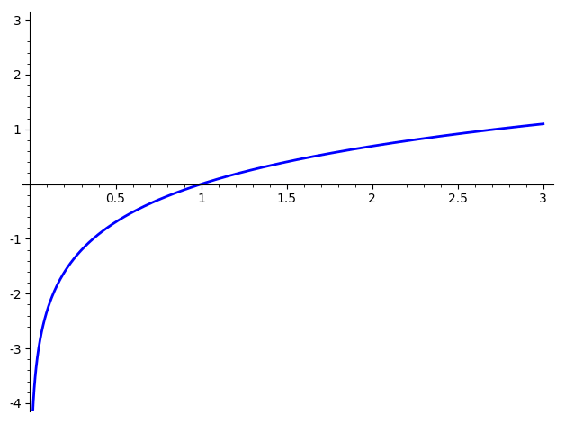

```python
plot_f_taylor(log(x), 1, (0, 3), (-4, 3), 10)
```

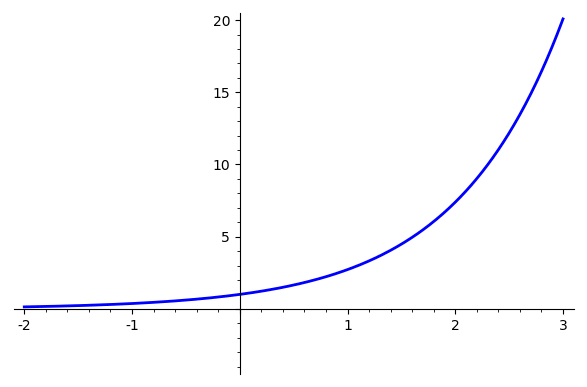

```python
plot_f_taylor(exp(x), 1, (-2, 3), (-4, 20), 10)
```

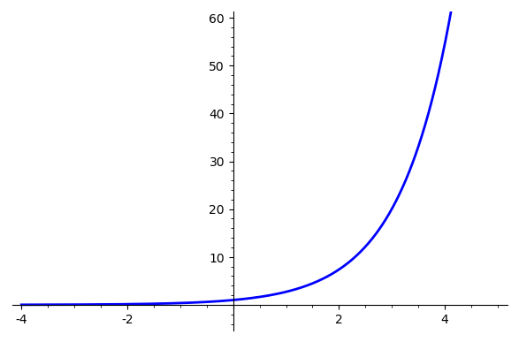

```python
plot_f_taylor(exp(x), 1, (-4, 5), (-4, 60), 10)
```

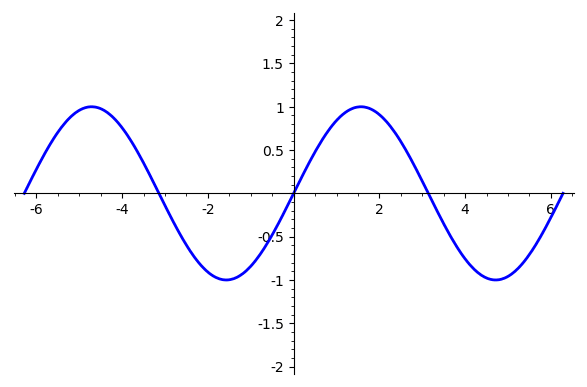

```python
plot_f_taylor(sin(x), 0, (-2*pi, 2*pi), (-2, 2), 20)
```